# The statistical value chain and data validation

uRos2018 Tutorial Session, The Hague

## The Statistical Value Chain

## Value Chains

### Porter’s value chain (1985)

*The idea of the value chain is based on the process view of organizations, the idea of seeing a manufacturing (or service) organization as a system, made up of subsystems each with inputs, transformation processes and outputs.*

## Statistical Value Chain

### Notes

- This part only pertains to the data processing stage. Collection, design, dissemination is not included.
- The fixed points are well-defined statistical products.

## Stages in the SVC

1. **Raw Data** is data as it arrives
   - Can differ in quality/source: survey/admin/big data
2. **Input data** satisfies technical demands:
   - File type is known and can be read
   - Variables are of correct type (number/date/text/categorical\(...\))
   - Records identified with statistical objects
   - Variables identified with statistical properties

## Stages in the SVC

1. **Valid data** satisfies domain knowledge constraints
   - Age cannot be negative
   - Someone under 15 yrs old cannot have income from work
   - mean economic growth/decline does not exceed 5% in a certain sector
   - \(...\)

### Justification

Invalid data leads to invalid statistical results.

## Stages in the SVC

1. **Statistics** are the target output values (aggregates) describing the population characteristic of interest.
   - Economic growth
   - Unemployment
   - Income distribution
   - GDP
   - \(\ldots\)

### Note

Statistics also need to satisfy domain knowledge constraints.

## Stages in the SVC

1. **Output** are statistics, formatted and annotated for publication
   - Figures, tables
   - Definitions
   - \(..\)

## The SVC: Remarks

- Actual data processing is not necessarily linear accross the chain
- In production architectures a more flexible model is often used where the definition of interfaces between processing steps play a crucial role. The chain shown here is a general example covering most steps in some way.

## Data validation

### Definition (ESS handbook on validation)

*Data validation is an activity in which it is verified whether or not a combination of values is a member of a set of acceptable value combinations.*

### Validation rules

The set of acceptable values combinations are defined by *validation rules*, e.g. `IF age <= 14 THEN has_job == "no"`.

### Observe

*validation rules define, to large extend, the products in the SVC*

## `validate`: *data validation infrastructure for R*

### A domain-specific language for rule definition

Define *any* check on your data, using the *full power* of the R language.

### Rules as first-class citizens

- CRUD operations (create, read, update, delete)
- Summarize, plot, investigate rules
- Rich metadata

### Validate data

- Confront data with rules
- CRUD on results, summarize, plot
- Export to ESS standard reporting format (upcoming)

## Assignment 1

Try the following code.

```r
library(validate)
library(magrittr)
data(retailers)
head(retailers)
retailers %>%
  check_that(turnover + other.rev == total.rev
             , turnover > 0, other.rev > 0 ) %>%
  summary()
```

## Assignment 1

```r
library(validate)
library(magrittr)
data(retailers)
retailers %>%
  check_that(turnover + other.rev == total.rev
             , turnover > 0, other.rev > 0 ) %>%
  summary()
```

```
##   name items passes fails nNA error warning
## 1   V1    60     19     4  37 FALSE   FALSE
## 2   V2    60     56     0   4 FALSE   FALSE
## 3   V3    60     23     1  36 FALSE   FALSE
##                                      expression
## 1 abs(turnover + other.rev - total.rev) < 1e-08
## 2                                  turnover > 0
## 3                                 other.rev > 0
```

## Data validation with `validate`

```r
library(validate)
data(retailers)
head(retailers,3)[3:7]
```

```
##   staff turnover other.rev total.rev staff.costs
## 1    75       NA        NA      1130          NA
## 2     9     1607        NA      1607         131
## 3    NA     6886       -33      6919         324
```

## Data validation with `validate`

```r
rules <- validator(
   turnover >= 0
  , other.rev >= 0
  , turnover + other.rev == total.rev
)

out <- confront(retailers, rules)
summary(out)
```

## Assignment 2

1. Adapt the previous exercise so you use `validator`.
2. Use `confront` for validation and store the results in a variable called `out`.
3. Try `plot(out)`.
4. Try `as.data.frame(out)` (use `View` to inspect the result)

## Plotting output

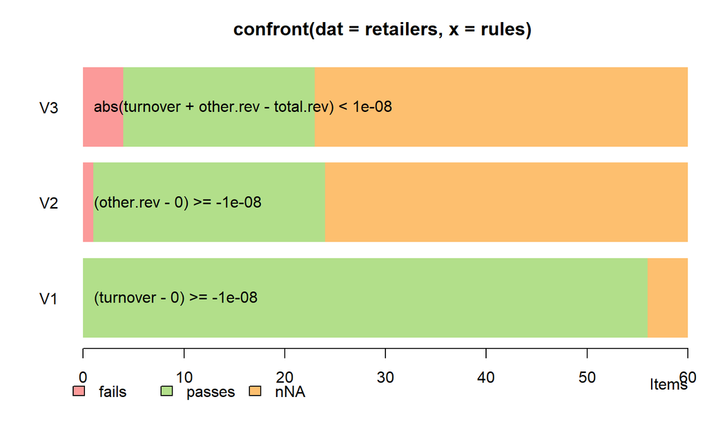

```r
plot(out)
```

## The validate package

[figure not shown]

## Reading rules from file

```r
### myrulez.txt

# some basic checks
staff >= 0
turnover >= 0
other.rev >= 0
# account balance checks
turnover + other.rev == total.rev
# other commom sense stuff
if (staff >= 1) staff.costs >= 1
```

```r
rulez <- validator(.file="myrulez.txt")
```

## Domain Specific Language

### Validation DSL

Any R statement resulting in a `logical`.

### Examples

```r
# Range checks
has_job %in% c('yes','no')
turnover >= 0
# Multivariate checks
abs(profit) <= 0.6 * turnover
# Multi-row checks
mean(profit) > 10
# Logical implications
if (staff > 0) staff.costs > 0
```

## Validation DSL

### Comparisons

`>, >=,==, <=, <, %in%`

### Boolean operations

`!, all(), any(), &, &&, |, ||, if () else`

### Text search

`grepl`

### Functional dependencies (Armstrong)

`city + zipcode ~ streetname`

### Refer to the dataset with `.`

`nrow(.) == 40`, `"turnover" %in% names(.)`

## Transient assignments (macros) using `:=`

### Example 1

\[ \max\left(\frac{x}{x^*},\frac{x^*}{x}\right) \leq 10 \]

```r
med := median(turnover,na.rm=TRUE)
hb := pmax(turnover/med, med/turnover, na.rm=TRUE)
hb <= 10
```

### Example 2

```r
beta_2 := coefficients(lm(turnover ~ profit))[2]
beta_2 >= 0
```

## Variable groups

### Many variables, same rule

```r
G := var_group(staff, turnover, other.rev, total.costs)
G >= 0
```

## Error handling

```r
out <- check_that(women, hite > 0, weight>0)
out
```

```
## Object of class 'validation'
## Call:
##     check_that(women, hite > 0, weight > 0)
##
## Confrontations: 2
## With fails    : 0
## Warnings      : 0
## Errors        : 1
```

```r
errors(out)
```

```
## $V1
## [1] "object 'hite' not found"
```

## Assignment 3

1. Create a new textfile
2. Define 10 rules for the `retailers` dataset
3. Read the rules (`validator(.file="your file")`)
4. `confront` rules with data
5. Summarize and plot the results.
6. Use `as.data.frame` and `View` to convert and display the results.
7. Make a `plot` of the `validator` object.

## Naming rules

```r
rules <- validator(
  to_pos = turnover >= 0
  , or_pos = other.rev >= 0
  , balance = turnover + other.rev == total.rev)
rules
```

```
## Object of class 'validator' with 3 elements:
##  to_pos : turnover >= 0
##  or_pos : other.rev >= 0
##  balance: turnover + other.rev == total.rev
```

## Rule selection

```r
rules[1:2]
```

```
## Object of class 'validator' with 2 elements:
##  to_pos: turnover >= 0
##  or_pos: other.rev >= 0
## Rules are evaluated using locally defined options
```

```r
rules["balance"]
```

```
## Object of class 'validator' with 1 elements:
##  balance: turnover + other.rev == total.rev
## Rules are evaluated using locally defined options
```

## Rule metadata

```r
rules[[3]]
```

```
##
## Object of class rule.
##  expr       : turnover + other.rev == total.rev
##  name       : balance
##  label      :
##  description:
##  origin     : command-line
##  created    : 2018-09-12 09:31:32
##  meta       :
```

## More manipulation: combining rule sets

```r
validator(x > 0) + validator(x <= 1)
```

```
## Object of class 'validator' with 2 elements:
##  V1  : x > 0
##  V1.1: x <= 1
```

## Export rules & metadata to and import from `data.frame`

### Create data frame

```r
rules_df <- as.data.frame(rules)
```

### Read from data frame

```r
myrules <- validator(.data = rules_df)
```

## Setting options

### Global options

```r
# stop at error instead of catching
voptions(raise="all")
```

### Options per object

```r
# value to replace NA outcomes
voptions(rules, na.value=FALSE)
```

### When confronting data with rules

```r
out <- confront(retailers, rules
        , lin.eq.eps=1e-2 )
```